# Chapter 5 - Statistical Thermodynamics

Date: Monday, 2020-10-05

We saw early in the course that the bulk thermodynamic properties of molecules are a consequence of the *average* properties of individual parts of an ensemble. For example, we saw that the average kinetic energy depends on the average velocities of the atoms, and that for an ideal, monoatomic gas, the energy of the system is simply: $$\tfrac{3}{2} RT = \tfrac{1}{2}M\left< v^2 \right>$$

where $\left< v^2 \right>$ is the mean square velocity of all of the atoms in the system.

We also saw in the introductory lectures, that distributions in chemistry are often assumed to be Gaussian, but that's not always the case.

Here we plot some commonly encountered distributions in chemistry: Gaussian ("Normal"), Lorentzian ("Cauchy"), and Maxwellian.

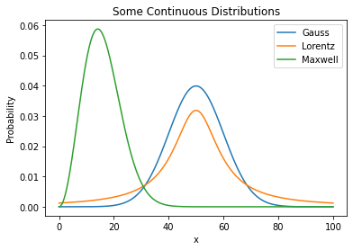

```python
import numpy as np
import matplotlib.pyplot as plt
from scipy import stats
# define some x and y values to plot:
x = np.linspace(0,100,1000) # generate 1000 linearly spaced values from 0 to 100
loc = 50; scale = 10 # parameters describing scipy distributions
y = stats.norm.pdf(x, loc=loc, scale=scale) # compute probability y values for each x
y1 = stats.cauchy.pdf(x, loc=loc, scale=scale) # compute probability y values for each x
loc2 = 0; scale = 10
y2 = stats.maxwell.pdf(x, loc=loc2, scale=scale) # compute probability y values for each x
#plt.plot(x, y, 'r-', lw=2, alpha=0.6)
plt.plot(x, y, label="Gauss")
plt.plot(x, y1, label="Lorentz")
plt.plot(x, y2, label="Maxwell")
plt.title('Some Continuous Distributions')
plt.xlabel('x'); plt.ylabel('Probability')
plt.legend()
plt.show()
```

## The Boltzmann Distribution

Q: how are the velocities (i.e., kinetic energies) distributed around the average value of $\tfrac{3}{2}RT$?

[figure not shown]

Consider two possible values for the kinetic energy of a particle $\tfrac{1}{2}m\nu^2$. We can expect that relative probabilities of a particle adopting the two energies should depend in some way on the energy difference between them, so that lower energy states might be more favored:

$$p_2/p_1 = f\left(E_1-E_2\right)$$

Likewise, if we introduce a third energy level we have

$$E_3 - E_1 = (E_3 - E_2) + (E_2 - E_1)$$

and the population ratios

$$\frac{p_3}{p_1} = \frac{p_3}{p_2}\times\frac{p_2}{p_1}$$

It follows then that the relation between populations of E3 and E1 is a *product* of the others

$$f(E_3-E_1) = f(E_2-E_1)\times f(E_2-E_1)$$

This relation is satified when the probabilities are a related to a negative exponential of *E*:

$$p_i = Ne^{-E_i\beta}$$

where *N* is a normalization factor and $\beta$ is an as-yet specified multiplication factor that has reciprocal units as *E* (so we are not rasing *e* to a power with units).

We will see that $\beta$ is $1/k_BT$.

## Maxwell-Boltzmann Distribution of Velocities

[figure not shown]

To specify the translational motion of a particle, we need to know more than its energy, since velocity is a *vector* with both magnitude and direction: $$\nu^2 = \bf{v}\cdot\bf{v}$$

The *speed* $\nu$ is the *magnitude* component of the velocity vector $\bf{v}$, and can be represented by the length of an arrow pointing in infinite directions on the surface of a sphere (Figure 5.2).

We can *quantize* speed, by grouping vectors with speeds between $\nu_i$ and $\nu_i + d\nu$. The *number* of vectors with speeds between those two values is the *degeneracy*, $g_i$ of that speed. That degeneracy can be quantified as the volume of that slice aroudn the sphere, $g_i = 4\pi\nu_i^2d\nu$. If $\nu_2 = 2\nu_1$, then

$$g_2/g_1 = \frac{4\pi\nu_2^2d\nu}{4\pi\nu_1^2d\nu} = \frac{\nu_2^2}{\nu_1^2} = 4$$

that is, the degeneracy (number of vectors with that range of velocities) is 4 times greater. Thus the degeneracy for the vectors with velocity between $\nu_i$ and $\nu_i + d\nu$,

$$g_i \propto 4\pi\nu_i^2d\nu$$

and the probability of that velocity range

$$p_id\nu \propto 4\pi\nu_i^2 d\nu \times e^{-\beta E_i} = 4\pi N\nu_i^2d\nu \exp\left(-\tfrac{1}{2}\beta m\nu_i^2\right)$$

where *N* is the normalization factor. The normalization factor can be evaluated by integrating over all possible energies (velocities): $$\int^\infty_0p(\nu)d\nu = 1 = \int^\infty_0 4\pi N\nu^2\exp\left(-\tfrac{1}{2}\beta m\nu^2\right)d\nu$$ yielding $$ N = \left(\frac{\beta m}{2\pi}\right)^{3/2}$$

Then, to determine $\beta$ we evaluate the integral of Energy over all possible values of $\nu$

$$\left<E\right> = \int^\infty_0 E(\nu)p(\nu)d\nu = \underbrace{\left(\frac{\beta m}{2\pi}\right)^{3/2}}_{\text{normalization}} \int_0^\infty \left[\underbrace{\tfrac{1}{2}m\nu^2}_{Energy} \times \underbrace{4\pi \nu^2 \exp\left(-\tfrac{1}{2}\beta m\nu^2\right)}_{probability}\right]d\nu $$

This yields the simple solution

$$\left<E\right> = \frac{3}{2\beta}$$

So, the energy of molecules in that velocity range is $3/2$ times $1/\beta$.

If follows that $\beta = \frac{1}{k_BT}$, wherein on a molar scale the energy is $$U = \frac{3}{2}RT = N_A\frac{3}{2}k_BT$$

Substituting $\beta$ into the expressions above,

$$N = \left(\frac{m}{2\pi k_B T}\right)^{3/2} = \left(\frac{M}{2\pi RT}\right)^{3/2}$$

and the Maxwell-Boltzmann speed distribution:

$$p(\nu)d\nu = \sqrt{\frac{2}{\pi}}\left(\frac{M}{RT}\right)^{3/2}\nu^2 \exp\left(\frac{-M\nu^2}{2RT}\right)d\nu$$

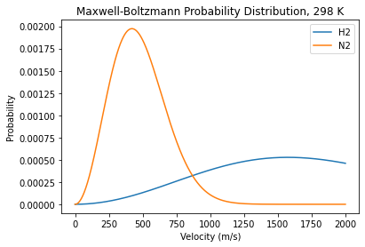

```python
import numpy as np
import matplotlib.pyplot as plt
R = 8.314
T = 298
# define list of labels, masses (and temperatures?) for analysis
list = [("H2", 2.0), ("N2",28.0)]
x = np.linspace(0,2000,1000) # generate 1000 linearly spaced values from 0 to 2000
# Maxwell-Boltzmann; take x values, mass, T and inputs
def f_mb(x,M,T):
    return np.sqrt(2/np.pi)*(M/R/T)**(3/2)*x**2*np.exp(-M*x**2/2/R/T)

fig, ax = plt.subplots()
for i in list:
    M=i[1]/1e3; label = i[0] # convert g/mol tp kg/mol
    y = f_mb(x,M,T)
    plt.plot(x,y, label=label)

plt.xlabel('Velocity (m/s)')
plt.ylabel('Probability')
plt.legend()
plt.title('Maxwell-Boltzmann Probability Distribution, %d K' % T)
plt.show()
```

## Maxwell-Boltmann Distribution and Speed

In addition to probability and energy, we can use the Maxwell-Boltmann Distribution to compute mean speed: $$\left<\nu\right> = \int^\infty_0\nu p(\nu)d\nu = \sqrt\frac{2}{\pi}\left(\frac{M}{RT}\right)^{3/2}\int_0^\infty\left[\nu\times\nu^2\exp\left(\frac{-M\nu^2}{2RT}\right)\right]d\nu$$

the integral of which simplifies to:

$$\left<\nu\right> = \sqrt{\frac{8RT}{\pi M}}$$

and the mean squared speed:

$$\left<\nu^2\right> = \sqrt\frac{2}{\pi}\left(\frac{M}{RT}\right)^{3/2}\int_0^\infty\left[\nu^2\times\nu^2\exp\left(\frac{-M\nu^2}{2RT}\right)\right]d\nu = \frac{3RT}{M}$$

Last, we consider the most probable speed, which corresponds to the top of the distribution, where the derivative with respect to velocity is zero:

$$\frac{dp(\nu)}{d\nu} = \sqrt\frac{2}{\pi}\left(\frac{M}{RT}\right)^{3/2}\left[2\nu\exp\left(\frac{-M\nu^2}{2RT}\right)-\nu^2\left(\frac{M\nu}{RT}\right)\exp\left(\frac{-M\nu^2}{2RT}\right)\right]=0$$

which reduces to

$$\nu_{mp} = \sqrt{\frac{2RT}{M}}$$

```
H2    Most probable:    1574 m/s; Average:    1776 m/s; RMS:    1928 m/s
N2    Most probable:     421 m/s; Average:     475 m/s; RMS:     515 m/s
O2    Most probable:     394 m/s; Average:     444 m/s; RMS:     482 m/s
```

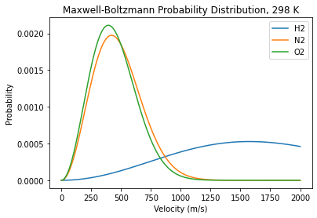

```python
import numpy as np
import matplotlib.pyplot as plt
R = 8.314
T = 298
# define list of labels, masses (and temperatures?) for analysis
list = [("H2", 2.0), ("N2",28.0), ("O2", 32.0)]
x = np.linspace(0,2000,1000) # generate 1000 linearly spaced values from 0 to 2000
# Maxwell-Boltzmann; take x values, mass, T and inputs
def f_mb(x,M,T):
    return np.sqrt(2/np.pi)*(M/R/T)**(3/2)*x**2*np.exp(-M*x**2/2/R/T)

fig, ax = plt.subplots()
for i in list:
    M=i[1]/1e3; label = i[0] # convert g/mol tp kg/mol
    v_mp = np.sqrt(2*R*T/M) # most probably velocity
    v_av = np.sqrt(8*R*T/np.pi/M) # average velocity
    v_rms = np.sqrt(3*R*T/M) # root-mean-square velocity
    print('{:5s} Most probable: {:7.0f} m/s; Average: {:7.0f} m/s; RMS: {:7.0f} m/s'.format(i[0],v_mp, v_av, v_rms))
    y = f_mb(x,M,T)

    plt.plot(x,y, label=label)

plt.xlabel('Velocity (m/s)')
plt.ylabel('Probability')
plt.legend()
plt.title('Maxwell-Boltzmann Probability Distribution, %d K' % T)
plt.show()
```

```
H₂      Most probable:    1574 m/s; Average:    1776 m/s; RMS: 3716358 m/s
N₂      Most probable:     421 m/s; Average:     475 m/s; RMS:  265454 m/s
```

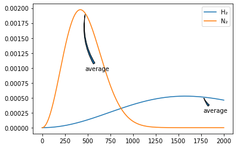

```python
# make a list of the masses to evaluate; optionally, could include a T as part of the list
list = [("H"+u'\u2082', 2.0), ("N"+u'\u2082',28.0)]
    # indicate locations of average and most probable speed
x = np.linspace(0,2000,1000) # generate 1000 linearly spaced values from 0 to 2000
def f_mb(x,R,T,M):
    return np.sqrt(2/np.pi)*(M/R/T)**(3/2)*x**2*np.exp(-M*x**2/2/R/T)

fig, ax = plt.subplots()
for i in list:
    M=i[1]/1e3; label = i[0]
    y = f_mb(x,R,T,M)
    plt.plot(x,y, label=label)

    v_mp = np.sqrt(2*R*T/M) # most probably velocity
    label_X = v_mp
    label_Y = f_mb(v_mp,R,T,M)
    label_text = 'most probable'

    v_av = np.sqrt(8*R*T/np.pi/M) # average velocity
    label_X = v_av
    label_Y = f_mb(v_av,R,T,M)
    label_text = "average"
    ax.annotate(label_text, xy=(label_X, label_Y), xytext=(label_X, label_Y/2),
             arrowprops=dict(arrowstyle="wedge",
                     connectionstyle="arc3,rad=-0.2"))
    v_rms = 3*R*T/M

    print('{:7s} Most probable: {:7.0f} m/s; Average: {:7.0f} m/s; RMS: {:7.0f} m/s'.\
          format(i[0],v_mp, v_av, v_rms))
plt.legend()
plt.show()
```

## Statistical Thermodynamics

[figure not shown]

Although the treatment above is valid for a *continuous* distribution (like speed), it also applies for *discrete* distributions, like quantized energy levels. This facilitates analysis of because we only need to count and sum populations, not take complicated integrals. Indeed, all bulk *macrosopic* thermodynamic properties ($U, q_{rev}, w_{rev}, S$) can be related to shifts in energy levels and populations.

For an ideal gas (because there are no interactions between molecules) the total energy *E* of a system can be represented by the sum of the energies of all molecules,

\begin{align} E &= N_1E_1 + N_2E_2 + ... N_iE_i \\ &=\sum_i{N_iE_i} \end{align}

where $N_i$ is the number of molecules in the energy level $E_i$.

### Work

[figure not shown]

Recall that for reversible expansion of a gas in a piston, the force applied by the external pressure

$$ w = \int F_{ex}dx = -\int p_{ex} dV$$

Since the force is applied by particles with a range of velocities (which we can place in bins), the force is the sum of the force applied by the individual groups of particles along the axis of expansion, *x*:

$$ F = -F_{ex} = \sum_i N_iF_{ix}$$

and the work done

$$dw = F_{ex}dx = -\sum_iN_iF_{ix}dx$$

[figure not shown]

With Force being the negative derivative of energy,

$$F_{ix} = -\frac{dE_i}{dx}$$

Hooke's law a spring with a force constant *k*, we have

$U = \tfrac{1}{2}k(x-x_0)^2$ and $F = -dU/dx = -kx$

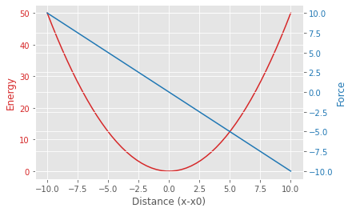

```python
'''
Hooke's law for a spring
Energy U = 1/2 kx^2, and force is its negative derivative: F = -dUdx = -kx, where k is the
proportionality between distance and energy

'''
import numpy as np
import matplotlib.pyplot as plt
%matplotlib inline
plt.style.use('ggplot')
x = np.linspace(-10,10)
k = 1
y1 = -k*x
y0 = (x)**2*k/2

fig, ax1 = plt.subplots()
color = 'tab:red'
ax1.set_xlabel('Distance (x-x0)')
ax1.set_ylabel('Energy', color=color)
ax1.plot(x, y0, color=color)
ax1.tick_params(axis='y', labelcolor=color)

ax2 = ax1.twinx()  # instantiate a second axes that shares the same x-axis

color = 'tab:blue'
ax2.set_ylabel('Force', color=color)  # we already handled the x-label with ax1
ax2.plot(x,y1, color=color)
ax2.tick_params(axis='y', labelcolor=color)

#fig.tight_layout()  # uncomment if the right y-label is clipped
plt.show()
```

So we find that the work done results is a change in the energy levels $E_i$ due to the change in volume: $$dw_{rev} = -\sum_i N_i\left(\frac{dE_i}{dx}\right)dx = \sum_i N_idE_i$$

## Heat

Likewise, we show that heat flow *q* is related to statistical properties. To do this we consider how the energy of a system changes with changes in energy levels and populations:

$$dE = \underbrace{\sum_i N_idE_i}_{\text{change}\\\text{in levels}\\=dw_{rev}} + \underbrace{\sum_i dN_i E_i}_{\text{change in populations}}$$

Equating total energy *E* with thermodynamic internal energy *U* (relative to 0K): that is, $dE = q + w$, we find that

$$dq_{rev} = \sum_i dN_i E_i$$

which tells us that heat flow changes the *distribution* of molecules between the available energy levels.

Thus, *w* changes the energy levels, and *q* changes populations among them.

## Ensembles and Distributions

The statistical approach can be extended to *ensembles* of molecules, or more broadly, *ensembles of systems* with *E* being the sum of the energies of the ensembles, $E = \sum_iN_iE_i$ and the average energy determined from the number of systems in each energy level $\left<E\right> = \frac{\sum_iN_iE_i}{N}$.

We will see that there are many ways to arrange the systems to arrive at a particular energy, but that there is a *most probable distribution* that dominates.

## Probabilities (Most Probable Distribution)

[figure not shown]

We considered that entropy would drive the dissipation of dye molecules in a solution to one of maximum disorder. We understand that the equilibrium configuration is the most probable one, and that the probability of dye molecules spontaneously, and stochastically aggregating themselves back into a concentrated droplet is infinitessimaly small.

We will explore these probabilities using classical statistical approaches. Consider for example, flipping of a coin. Provided the coin in balanced, the probability of yielding a head (H) or tail (T) is the same; i.e., 1/2.

[figure not shown]

If we get a H after the first trial (p=1/2), what is the probaility of getting another head?

$$p = \frac{1}{2}\times\frac{1}{2}=\frac{1}{4}$$

In fact, that's the probability of any outcome of two coin tosses, since the probability of each outcome at each trial is 1/2. For four coin tosses,

$$p = \frac{1}{2}\times\frac{1}{2}\times\frac{1}{2}\times\frac{1}{2}=\frac{1}{16}$$

[figure not shown]

Obviously, as the number of trials increases, the probability of a given outcome *decreases*, since there are so many alternative, *equally probable* outcomes.

### Aggregate outcomes and multiplicity

Instead of a given sequence of outcomes, we consider the aggregate result (number of outcomes of a given kind). This probability:

$$P = \frac{\text{number of desired outcomes}}{\text{number of total outcomes}}$$

where the *number of desired coutomes* is the number of ways of achieving the result of interest - termed its **multiplicity**. With four coin tosses, we can categorize the aggregate outcomes:

[figure not shown]

For $2^4 = 16$ *outcomes* we see only one way of achieving 4 heads and 4 tails, 4 ways of achieving 1 head or 1 tail, and 6 ways of achieving two heads and two tails. The probability of each aggregate outcome (since individual trials have equal probability) is a function of is **multiplicity**, or **degeneracy**, $g_i$. We see that the probability of getting two H and 2 T, in any order is $6/16 = 0.38$.

Date: Wednesday 2020-10-07

- Binomial Statistics
- Breakout
- Reconvene
- Partition Function
- Carmen Quiz

## Bionomial Statistics

When flipping 4 coins, there are $2^4 = 16$ possible outcomes. When considering aggregate outcomes (not their order), we find that the most probable outcome has two heads and two tails, since there are 6 possible ways of achieving that result. In order from 0 to 4 tails, the degeneracies are:

| Tails | $g$ |
| --- | --- |
| 0 | 1 |
| 1 | 4 |
| 2 | 6 |
| 3 | 4 |
| 4 | 1 |
| -- | -- |

The multiplicity of each outcome can be determined from:

$$W(M,N) = \frac{M!}{N!(M-N)!}$$

which tells us the number of ways to getting *N* binary outcomes (head/tail) in *M* trials. So, the multiplicity of getting two heads ($N = 2$) from four flips ($M=4$):

$$W(4,2) = \frac{4!}{2!(4-2)!} = \frac{24}{2 \times 2} = 6$$

consistent with the table and figure above.

[figure not shown]

Binomial statistics (binary outcome: heads/tails) have many applications to biochemical problems. Consider for example, the case of a dimeric receptor protein that has two identical binding sites for a ligand. If the ligand is present at concentrations in which 1/2 of the sites can be occupied, it is important to consider how the ligands will be distributed among available sites. If the probability of each site being filled is 1/2 (and the sites don't interact), that's equivalent to the binary H/T coin-flip problem, and we can see that the most probable arrangement has dimers with one site bound, with overall *W* ratios of 1:2:1 for 0, 1, and 2 bound ligands.

[figure not shown]

This pattern can be expanded graphically using Pascal's triangle, and follows the binomial theorem $(x+y)^n$, wherein the rows are the number of trials and the binomial coefficients report the multiplicity of the outcome. We see, for example, that four binary trials yields multiplicities of 1:4:6:4:1, as we saw above. Note that as the number of trials increase, the probabilities at the edges of the triangle (i.e., the probability of a unique ouctome) becomes vanishingly small. For 8 trials, the probability of getting 4 heads (and 4 tails),

$$W(8,4) = \frac{8!}{4!(8-4)!} = \frac{8!}{4!4!} = 70$$

is 70 times more likely than getting 8 heads or 8 tails.

```python
# multiplicity of binary outcomes: W(M,N) = M!/(N!(M-N)!)
import math
M = 8; N = 4
def multiplicity(M,N):
    return math.factorial(M)/(math.factorial(N)*math.factorial(M-N))
print("Multiplicity of %d trials with %d outcomes: %d" %
      (M,N, multiplicity(M,N)))
```

```
Multiplicity of 8 trials with 4 outcomes: 70
```

**Breakout Exercise:** Show, using the binomial theorem $(x+y)^n$ that the binomial coefficients of match values in Pascal's triangle for $n = 1...4$

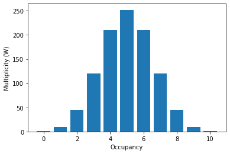

```python
# Let's plot some binomial distributions
import numpy as np
import math
import matplotlib.pyplot as plt
M = 10
lcoef=np.arange(0,M+1) # list of coefficients is N+1
def multiplicity(M,N):
    return math.factorial(M)/(math.factorial(N)*math.factorial(M-N))
W = np.zeros(len(lcoef)) # initialize array of length ncoef
for i in lcoef:
    W[i] = multiplicity(M,i)

plt.bar(lcoef,W)
plt.xlabel('Occupancy')
plt.ylabel('Multiplicity (W)')
plt.show()
```

**Stirling's Approximation**

When the number of trials becomes large, even computers struggle with computing $N!$. For large numbers of integers *n* the approximation is:

$$\ln n! \approx n\ln n -n$$

So, to compute W, we take the log of:

$$W(M,N) = \frac{M!}{N!(M-N)!}$$$$\ln W(M,N) = \ln\frac{M!}{N!(M-N)!} = \ln M! - (\ln N! + \ln(M-N)!)$$

then we replace each of the terms $\ln n!$ with Sterlin's approximation, $n \ln n -n$

```python
# sterling's approximation
import math
def sterling(n):
    return n*math.log(n) - n

list = 10,50,100, 500
#list = 10,50,100, 1000, 10000
print("%5s, %8s, %8s" % ("n", "n!", "n*ln(n)-n"))
for n in list:
    print("%5d, %8.2e, %8.2e" % (n, math.log(math.factorial(n)), (sterling(n))))
#    print("%5d, %7.2e" % (n, sterling(n)))
```

```
    n,       n!, n*ln(n)-n
   10, 1.51e+01, 1.30e+01
   50, 1.48e+02, 1.46e+02
  100, 3.64e+02, 3.61e+02
  500, 2.61e+03, 2.61e+03
```

### Binomial Distribution

[figure not shown]

We return for a moment to the application of the binomial theorem to receptors with *N* identical sites. We see that the most probable populations have the most degeneracy, in a pattern that follows Pascal's triangle.

> NB: Although we commonly refer to this pattern of numbers after the French mathematician, Blaise Pascal, for his work in the 1600s, there is evidence the binomial distribution was known at least 1,000 years earlier by scholars in Asia and the middle east.

When considering the occupancy of ligand binding sites, only unique conditions result in a probability of 1/2. More generally, if the probability of a binding site being occupied by ligand is *p*, then the probability that the site is unoccupied is (1 – *p*). The probability *P(M,N)* of finding *N* binding sites occupied in a receptor complex with *M* binding sites is then given by:

$$P(M,N) = W(M,N)\times p^N\times (1-p)^{M-N}$$

which is a modified form of the binomial distribution and applies to situations in which there is a bias to a binary outcome (head/tail, or empty/full).

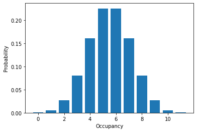

```python
# Now let's consider the distribution with arbitrary site occupancy probability
# P(M,N) = W(M,N)* p^N * (1-p)^(M-N)
import numpy as np
import matplotlib.pyplot as plt
M = 11
p = .5
lcoef=np.arange(0,M+1) # list of coefficients is M+1
def multiplicity(M,N):
    return math.factorial(M)/(math.factorial(N)*math.factorial(M-N))
def p_N(p,M,N):
    return p**N*(1-p)**(M-N)
W = np.zeros(len(lcoef)) # initialize array of length lcoef
pN = np.zeros(len(lcoef)) # initialize array of length lcoef
P = np.zeros(len(lcoef)) # initialize array of length lcoef

for i in lcoef:
    W[i] = multiplicity(M,i)
    pN[i] = p_N(p,M,i)
    P[i] = W[i]*pN[i]

# print(P)
plt.bar(lcoef,P)
plt.xlabel('Occupancy')
plt.ylabel('Probability')
plt.show()
# Change the parameters (p,M,N) to alter the distributions.
```

### Gaussian (Normal) Distribution

When M is large, the probability of obtaining a small number of outcomes is also small. Applying Stirling's to the binomial probability distribution

$$P(M,N) = \frac{M!}{N!(M-N)!}\times p^N \times (1-p)M-N$$

Allows us to reasonably pproximate the distribution as

$$P(N) = \frac{1}{\sqrt{2\pi}\times \sigma}exp\left[\frac{-(N-\mu)^2}{2\sigma^2}\right]$$

which is essential a Gaussian function, or normal distribution. The parameters $\mu$ and $\sigma$ are the mean and standard deviation of the distributions (*loc* and *scale* in the scipy.stats notation).

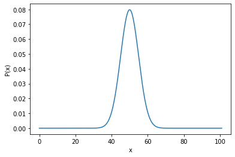

```python
# Gaussian/Normal distribution
import matplotlib.pyplot as plt
import numpy as np
import scipy.stats as stats
M = 100
p = 0.5
mu = M * p
sigma = np.sqrt(M*p*(1-p))
# mu and sigma are the parameters used by scipy.stats function (loc, scale)
x = np.linspace(0,M+1,1000)
y = 1/(np.sqrt(2*np.pi) * sigma)*np.exp((-(x-mu)**2)/2/sigma**2)
plt.plot(x,y)
plt.xlabel('x')
plt.ylabel('P(x)')
plt.show()
```

*We will return to binomial distributions and their use in random walks, and analysis of polymer behavior.*

### Multiplicity and Energy Levels

Likewise, let's consider a system with equally spaced energy levels, and a distribution such that the average energy of the system is $\left<E\right>=\varepsilon_0$:

[figure not shown]

When there are two *systems* ($N = 2$) there are two possible distributions with an average of $\varepsilon_0$: *one* with both systems at that energy, and *two* ways of having one system at $2\varepsilon$ and two at 0. Thus, so achieve the average energy $\varepsilon_0$ it is more likely achieved by the latter case.

Likewise, with $N=3$, there are more ways (6) to arrange systems so there is one in each of $0, \varepsilon_0,$ and $2\varepsilon_0$ than other possible configurations - that's what makes it more probable.

For any distribution, the number of ways of assigning energy levels to systems (i.e., arranging outcomes) is given by $$W = \frac{N!}{N_1!N_2!N_3!...} = \frac{N!}{\Pi_iN_i!}$$

This is the number of ways $N$ objects can be arranged in categories with $N_1$ in one, $N_2$ in another, etc. So, for the most probable outcome above, we consider how many ways to arrange 3 systems equally among three different energy levels: $$W = \frac{3!}{1!1!1!} = 6$$

That happens to be the most probable out come ($W^*$, in the figure).

**Example 5.1** Possible distributions of $N_i$ for an ensemble with $N=4$, with $\left<E\right> = \varepsilon_0$. Tabulating, for example:

| Case: | I | II | III | IV | V |
| --- | --- | --- | --- | --- | --- |
| 0 | 0 | 1 | 2 | 3 | 2 |
| $\varepsilon_0$ | 4 | 2 | 1 | 0 | 0 |
| 2$\varepsilon_0$ | 0 | 1 | 0 | 0 | 2 |
| 3$\varepsilon_0$ | 0 | 0 | 1 | 0 | 0 |
| 4$\varepsilon_0$ | 0 | 0 | 0 | 1 | 0 |
| $g$ | 1 | 12 | 12 | 4 | 6 |

Using our equation for permutations $W=N!/\Pi_iN_i!$, we find greatest multiplicity for the cases II and III, making these more probable configurations with an average energy of $\varepsilon_0$.

For an average energy of $\left<E\right>=\varepsilon_0$ there are two equally likely configurations that will dominate the distribution.

### Partition Function, $Q$

Given ensembles of systems with the same average energy $\left<E\right>$, the *most probable* distribution is given by the Boltzmann relation:

$$\frac{N_i}{N} = \frac{g_ie^{-E_i/k_BT}}{\sum_i g_ie^{-E_i/k_BT}}$$

where $g_i$ is the degeneracy of a state with $E_i$. This equation tells us that the population of each state *i* depends on its degeneracy $g_i$ and energy ($e^{-E_i/k_BT}$) compared to the *sum* of all other possible states, $\sum_i{e^{-E_i/k_BT}}$. The denominator is the *partition function*, $Q$:

$$\frac{N_i}{N} = \frac{g_ie^{-E_i/k_BT}}{Q}$$

and the ratios of systems/molecules in two different configurations is

$$\frac{N_j}{N_i} = \frac{g_je^{-E_j/k_BT}}{g_ie^{-E_i/k_BT}} = \frac{g_j}{g_i}e^{-(E_j-E_i)/k_BT}$$

For states with the same energy, the ratio will just be the ratios of degeneracies ($g_j/g_i$). These ideas connect back to the statistical thermodynamic definition of entropy

$$S = k_B \ln W$$

and supports the intuition that greater generacy is more probable and more random (less ordered).

**Example 5.2**

We use a statistical approach to revisit the entropy change in a two-chamber aparatus in which all of the gas is in the left chamber, vacuum in the right chamber, and is allowed to expand adiabatically upon opening the valve.

First, given our definition of entropy

$$S = k_B \ln W$$

The entropy difference between before and after opening the valve:

$$\Delta S = S_2 - S_1 = k_B \ln W_2 - k_B \ln W_1 = k_B \ln\frac{W_2}{W_1}$$

Before opening the valve, there is only one way to arrange molecules with respect to the vessel, so $W_1 = 1$. After opening the valve, molecules can be on either the left or right side of the chamber, $W_2 = 2$.

We can consider the left and right chambers as binary outcomes when counting molecules ($2^0 = 1 = \text{left}$, and $2^1 = 2 = \text{right}$). If we have two atoms, we have $2^2 = 4$ possible outcomes (in the ratio of 1:2:1). If we have 1 mol of molecules, the number of possible configurations before remains $W_1 = 1$, whereas after opening the valve we have $W_2 = 2^{N_A}$. Using the equation above, we find the expected result

$$\Delta S = k_B \ln\frac{W_2}{W_1} = k_B \ln\frac{2^{N_A}}{1} = N_A k_B \ln 2 = R \ln 2$$

### Partition Function; applications

The parttition function sums over all of hte energy states that a molecule can occupy

$$Q = \sum_i g_ie^{-E_i/k_BT}$$

Knowledge of the partition function allows us to compute other thermodynamic parameters (at east, for simple systems):

$$p = NK_BT\left(\frac{\partial\ln Q}{\partial V}\right)_T$$$$U = NK_BT^2\left(\frac{\partial\ln Q}{\partial T}\right)_V$$$$S=k_BN \ln Q + \frac{U}{T}$$

**Example 5.4** Derivation of the expression for the average energy of a system.

The average energy is obtained by summing the energies and probabilities of all states and dividing by the total.

$$\left<E\right> = \frac{\sum_i g_i E_i e^{-E_i/k_BT}}{Q}$$$$Q = \sum_i g_i e^{-E_i/k_B T}$$

The derivative of $e^{bx^n}$ with respect to $x$:

$$\frac{d}{dx}e^{bx^{n}} = \left(bnx^{n-1}\right)e^{bx^n}$$

So the partial derivative of $Q$ with respect to $T$ (at constant colume, so there is no work):

$$\left(\frac{\partial Q}{\partial T}\right)_V = \frac{1}{K_BT^2}\sum_i g_i E_i e^{-E_i/k_BT}$$

Substituting from our expression for the average energy (above) we get

$$ \left<E\right> = \frac{k_BT^2}{Q}\left(\frac{\partial Q}{\partial T}\right)_V $$

and since $\frac{dQ}{Q} = d \ln Q$,

$$ \left<E\right> = k_BT^2\left(\frac{\partial \ln Q}{\partial T}\right)_V $$

This shows how we can determine the average energy of we know the partition function, and take its derivative with respect to temperature (at constant volume).